# Befolkningsutvecklingen i Vansbro

Befolkningsutvecklingen i Vansbro  
- en kort analys

Rapporten är skapad av Samhällsanalys, Region Dalarna  
Senast uppdaterad: 2024-10-17

# Sammanfattning

Syftet med den här korta analysen är att undersöka Vansbros befolkningsutveckling. Ett antal viktiga slutsatser sammanfattas här:

- Nedgången i Vansbros folkmängd år 2023, jämfört med åren innan, beror på en svagare utveckling inom mer eller mindre alla komponenter som förklarar befolkningsutvecklingen.
- Det föddes färre barn i Vansbro 2023, jämfört med året innan, men fler än 2021 (och 2018). Samtidigt var barnafödandet per kvinna i Sverige 2023 det lägsta som har uppmätts.
- En stramare nationell migrationspolitik gör att färre invandrar till Sverige än tidigare, vilket även påverkar inflyttningen till Vansbro.
- Många, framförallt unga vuxna, flyttade från Vansbro till andra delar av Sverige under 2023. Att många flyttar från kommunen inrikes är normalt, men 2023 sticker ut som ett av de sämsta åren på 2000-talet på den punkten.

För mer info om statistiken, klicka på rutan nedan:

**Mer information om statistiken**

I folkmängden som SCB publicerar ingår personer som är folkbokförda i landet. För att den som flyttar till Sverige ska bli folkbokförd ska personen ha för avsikt och rätt att stanna i Sverige i minst ett år. För personer som inte är medborgare i ett EU-land innebär det att det krävs ett uppehållstillstånd som gäller minst 12 månader för att bli folkbokförd. Till följd av Rysslands invasion av Ukraina den 24 februari 2022 har Europeiska unionen (EU) beslutat att aktivera massflyktsdirektivet, vilket innebär att personer från Ukraina utan individuell prövning ska erbjudas tidsbegränsat uppehålls- och arbetstillstånd inom EU. Personer som får uppehållstillstånd enligt massflyktsdirektivet ska i regel inte bli folkbokförda och ingå i den officiella befolkningsstatistiken. Läs mer [här](https://www.scb.se/hitta-statistik/statistik-efter-amne/befolkning/befolkningens-sammansattning/befolkningsstatistik/produktrelaterat/Fordjupad-information/statistik-om-invandring---fragor-och-svar/).

Under 2023 inledde Skatteverket ett arbete med att granska registret över folkbokförda. Det förde med sig att SCB avregistrerade flera tusen folkbokförda personer som visade sig inte längre bo i Sverige. I folkbokföringen har dessa registrerats som utvandrade till okänt utvandringsland. Läs mer [här](https://www.scb.se/pressmeddelande/sverige-gar-mot-lagsta-befolkningsokningen-pa-manga-ar/).

All data som används i rapporten är offentlig och finns under kategorin befolkning i SCB:s [Statistikdatabas](https://www.statistikdatabasen.scb.se/pxweb/sv/ssd/). Där finns även data för exempelvis befolkningsutvecklingen under 2024 på månadsbasis, något som inte behandlas i denna rapport.

# 1 Hur har befolkningen förändrats?

I likhet med flera andra mindre kommuner i Dalarna har befolkningen i Vansbro minskat på lång sikt, från ca 9 300 invånare år 1968 till ungefär 6 700 invånare år 2023.

Befolkningen minskar under en överväldigande majoritet av åren, vilket syns tydligt i diagrammet nedan. Det stora undantaget var 2016, när Vansbros befolkning ökade med ungefär 170 personer. På senare år har befolkningsutvecklingen varit mestadels negativ, men 2022 ökade folkmängden med drygt 20 personer. Denna ökning följdes dock av en minskning år 2023 (-72 personer), den största minskningen sedan mitten på 00-talet.

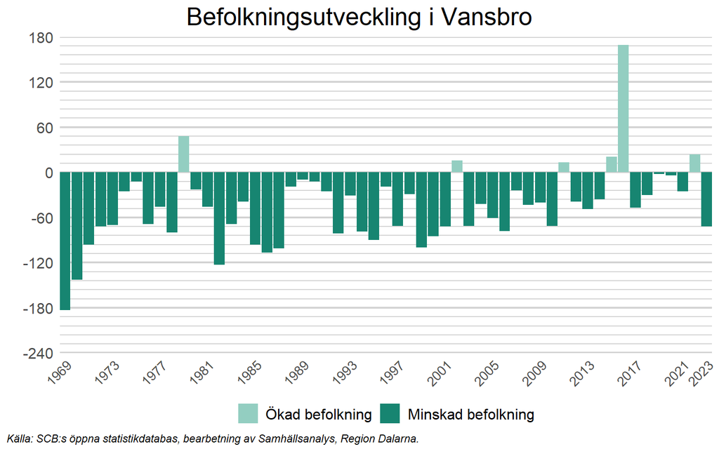

I fortsättningen av denna korta analys delas befolkningsutveckling upp i dess komponenter, födelsenetto, dvs. nettot av födda och döda, och flyttnetto, dvs. nettot av inrikes och utrikes flyttar.

# 2 Födelsenetto

En tydlig trend är att det dör färre personer boende i Vansbro idag än det gjorde längre tillbaka i tiden. Med undantag för Corona-pandemin, 2020 och 2021, dör idag mellan 80 och 90 personer under ett normalt år i kommunen. Detta kan jämföras med närmare 120 personer per år i början av 2000-talet och ibland över 150 personer per år på 1980-talet. Detta kan delvis förklaras av att färre idag bor i kommunen, men den främsta anledningen är framsteg inom det medicinska området.

Även när det gäller antalet födslar är trenden negativ. Under enstaka år på 1960- och 1980-talen föddes över 100 barn i Vansbro, men även en bit in på 2000-talet föddes relativt ofta över 70 barn i kommunen under ett år, något som inte har hänt sedan 2010. År 2023 föddes 53 barn, vilket är färre än året innan men samtidigt fler än 2021 (och 2018). Det finns dock vissa indikationer på att de låga födelsetalen 2023 är en del av en större trend. Enligt SCB var barnafödandet per kvinna i Sverige år 2023 det lägsta som har uppmätts, en trend som verkar hålla i sig under början av 2024 ([SCB](https://www.scb.se/pressmeddelande/historiskt-lagt-barnafodande-och-lagsta-folkokningen-pa-22-ar/)).

Sammantaget har nettot mellan födda och döda, se de svarta linjerna i diagrammet nedan, varit negativt i Vansbro under varje år sedan åtminstone slutet av 1960-talet. Hur många invånare som kommunen tappar på grund av det varierar relativt mycket mellan åren. År 2023 minskade befolkningen med 34 personer till följd av ett negativt födelsenetto.

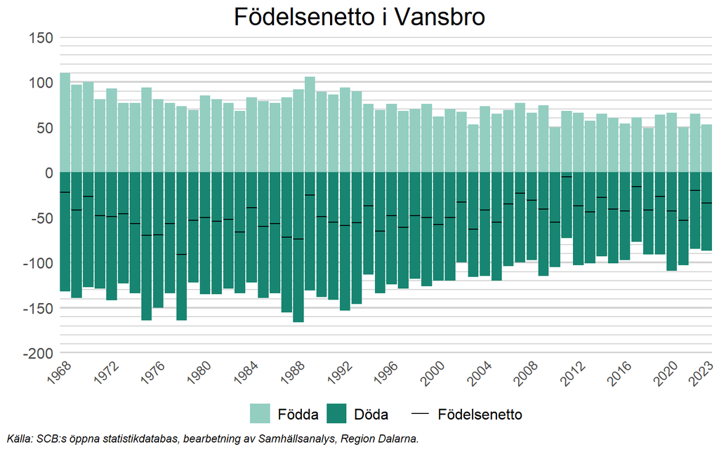

# 3 Flyttnetto

Den andra komponenten som styr befolkningsutvecklingen är det så kallade flyttnettot. Detta kan i sin tur delas upp i två komponenter, inrikes och utrikes flyttar. I det här avsnittet är fokus först på flyttnettot, innan de två komponenterna undersöks.

Nettot mellan antalet personer som flyttar till och från Vansbro varierar relativt mycket mellan åren, men ligger normalt mellan +/- 50 personer. Undantaget var 2015-2016, när drygt 270 personer netto flyttade till kommunen. På senare år har Vansbro haft ett positivt flyttnetto under flera år, men under 2023 var flyttnettot återigen negativt (-40 personer), det största negativa nettot sedan 2006. Intressant att notera är även att det positiva flyttnettot mestadels bestod av män under 2019 och 2020, för att därefter i praktiken bara bestå av kvinnor. Det negativa flyttnettot 2023 bestod även det av en överväldigande majoritet kvinnor.

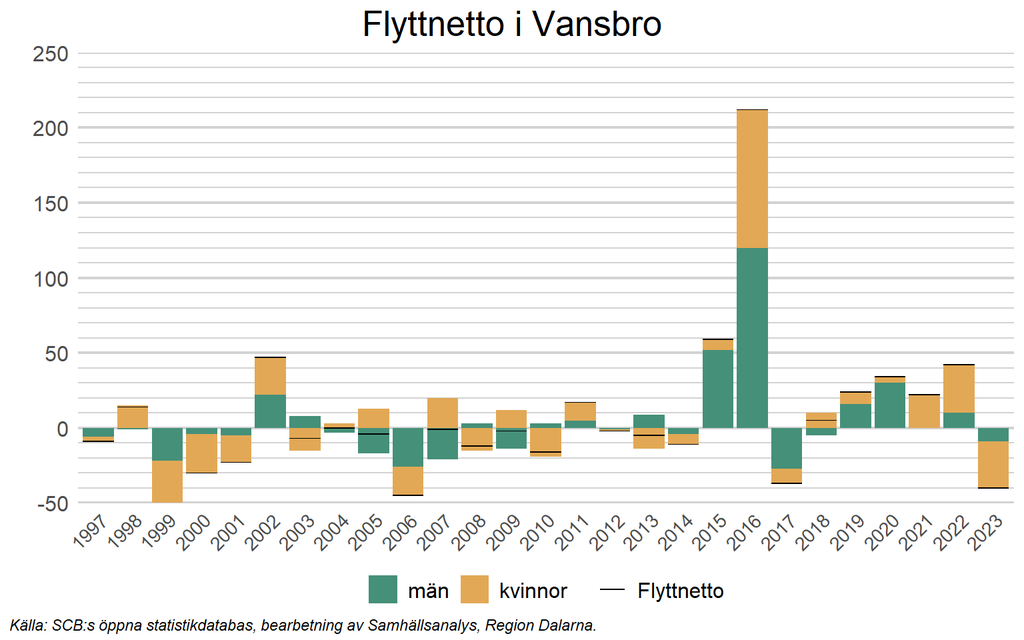

## 3.1 Utrikes flyttnetto

Som berördes i föregående avsnitt, flyttade många till Vansbro 2015-2016, vilket till viss del kan förklaras av att invandringen då var stor. I slutet av 1990-talet var invandringen låg eller till och med negativ under flera år (fler utvandrade än invandrade), men därefter skedde en gradvis ökning innan den stora toppen 2016. Därefter minskade invandringen tydligt, men låg på relativt höga nivåer fram till 2019. Under 2023 var det utrikes flyttnettot 8 personer, det lägsta nettot sedan 2001. Detta kan delvis förklaras av den avregistrering av utvandrade som Skattemyndigheten påbörjade under 2023 (se informationsrutan under avsnittet introduktion ovan), men den främsta anledningen är sannolikt en stramare nationell migrationspolitik.

Generellt invandrar ungefär lika många kvinnor och män, även om det har varit en viss övervikt för de sistnämnda efter på senare år. 2023 var det mestadels män som invandrade till Vansbro (netto).

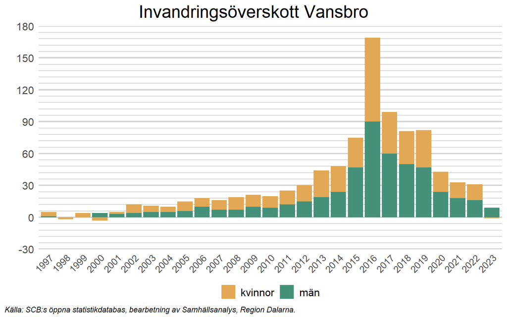

## 3.2 Inrikes flyttnetto

Utvecklingen för det inrikes flyttnettot är i mångt och mycket det omvända mot det utrikes, under de allra flesta åren sedan slutet på 1990-talet flyttade fler personer från Vansbro till andra delar av Sverige än de som flyttade till Vansbro. Framförallt var utflyttningen stor mellan 2017 och 2019. På senare år har det inrikes flyttnettot varit såväl positivt som negativt och relativt lågt, men år 2023 flyttade 48 personer netto från kommunen inrikes, vilket var klart fler än åren innan.

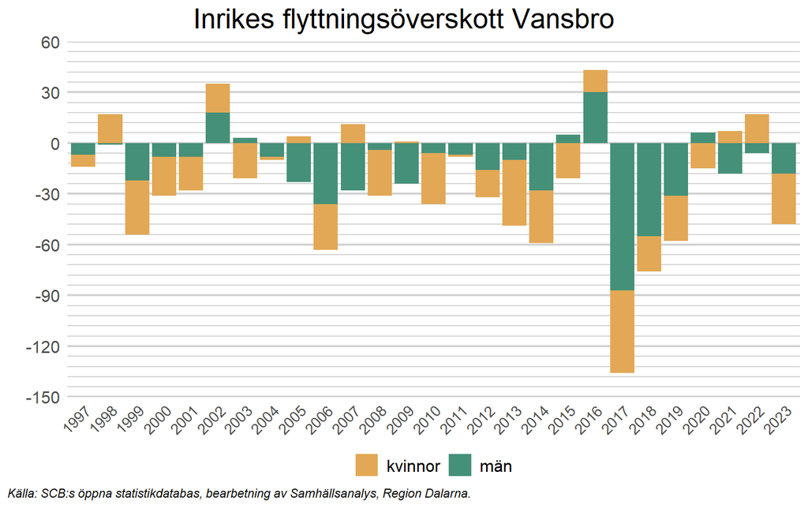

För att bättre förstå för vilka som flyttar till och från kommunen inrikes, delas de som flyttar härnäst upp efter ålder. Normalt är personer mest benägna att flytta till en annan ort när de är i 20-års åldern, innan flyttandet gradvis avtar.

### 3.2.1 Uppdelat på ålder

Ett tydligt mönster är att de personer under 30 år som flyttar från Vansbro är fler än de personer under 30 år som flyttar dit, dvs. kommunen förlorar invånare i den åldersgruppen på grund av inrikes flyttar. Inom andra åldersgrupper är tendenserna mer otydliga, då antalet in- och utflyttare (netto) varierar relativt mycket mellan åren. Med tanke på att Vansbro är en liten kommun är det även fullt möjligt att ingen inom en viss åldersgrupp flyttar till kommunen under ett specifikt år.

Bland de åldersgrupper som redovisas i diagrammet nedan skedde den största utflyttningen år 2023 i gruppen som är 20-29 år. I denna grupp, tillsammans med de som är under 20 år, var antalet uflyttare 59 fler än antalet inflyttare, vilket är en klart fler än åren innan.

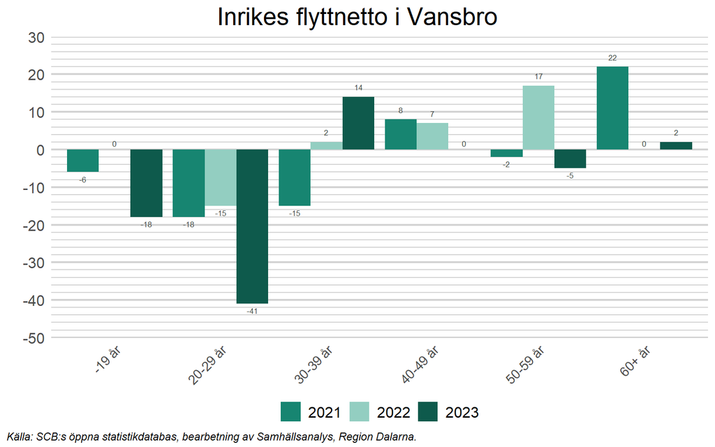

Om fokus enbart läggs på åldersgruppen 20-29 år, blir det tydligt att det i normala fall flyttar fler unga vuxna från än till kommunen inrikes. Historiskt varierar det inrikes flyttnettot i åldersgruppen mellan åren, vilket exempelvis kan bero på att olika årskullar av barn är olika stora. År 2023 flyttade 41 personer fler i åldersgruppen 20-29 år från än till kommunen inrikes, det största antalet på hela 2000-talet.

I Dalarna som helhet flyttade fler i åldersgruppen ut än in under 2023, vilket även gäller de flesta av länets kommuner.

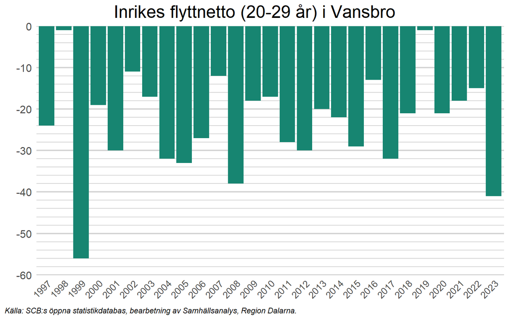

### 3.2.2 Uppdelat på bakgrund

För att ytterligare förtydliga vilka som flyttar till och från Vansbro inrikes, delas de i detta avsnitt upp efter sin bakgrund, inrikes eller utrikes födda.

Tydligt är att många av de som invandrade till Vansbro under framförallt 2015 och 2016 flyttade därifrån under åren därefter, då framförallt mellan 2017 och 2019. Sammantaget flyttade mer än 250 utrikes födda (netto) från Vansbro till andra delar av Sverige under den perioden. Med undantag för 2023, är det även tydligt att färre inrikes födda flyttar från Vansbro på senare år jämfört med åren mellan 2003 och 2013. En bidragande orsak till detta är sannolikt ett flertal expansiva arbetsgivare, något som medför att möjligheten att få jobb i kommunen idag är större än den var för 15 år sedan. Undantaget är som sagt 2023, då det inrikes flyttnettot i Vansbro var negativt och mestadels bestod av personer födda i Sverige.

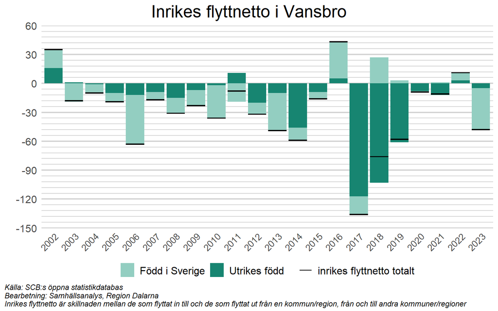

I nästa avsnitt är fokus istället på framtiden. Hur kommer Vansbros folkmängd att utvecklas fram till 2033?

# 4 Vad händer i framtiden?

För en djupare förståelse runt hur SCB gör befolkningsprognoser, se motsvarande avsnitt i rapporten för hela Dalarnas län. Det viktigaste att ha i åtanke är att ingen hänsyn tas i prognoserna till planerat bostadsbyggande, företagsetableringar eller andra framtida mål och förutsättningar som kommunerna har i sina planer.

I diagrammet nedan visas befolkningsutvecklingen i Vansbro fram till 2033 enligt SCB:s senaste prognos, uppdelat på åldersgrupper. Ett par tydliga trender kan utläsas i diagrammet:

- Vansbros befolkning prognostiseras att minska med drygt 340 personer fram till 2033, vilket är något fler än vid föregående prognos. I den prognosen, som släpptes 2022, prognostiserades en minskning på strax under 340 personer fram till 2033, jämfört med 2021 (se [SCB](https://www.statistikdatabasen.scb.se/pxweb/sv/ssd/START__BE__BE0401__BE0401B/BefProgRegFakN22/table/tableViewLayout1/)).
- Den största minskningen sker i åldersgruppen som brukar benämnas arbetsför ålder, 20-64 år, som prognostiseras minska med ungefär 250 personer.
- I åldergruppen 80+ förväntas befolkning att öka med ungefär 150 personer fram till 2033. Detta hänger sannolikt samman med att den förväntade livslängden fortsätter öka och att den stora gruppen “baby-boomers” börjar komma upp i 80-års åldern.
- Även i åldersgruppen 0-19 år sker en relativt stor minskning av befolkningen, ungefär 220 personer.

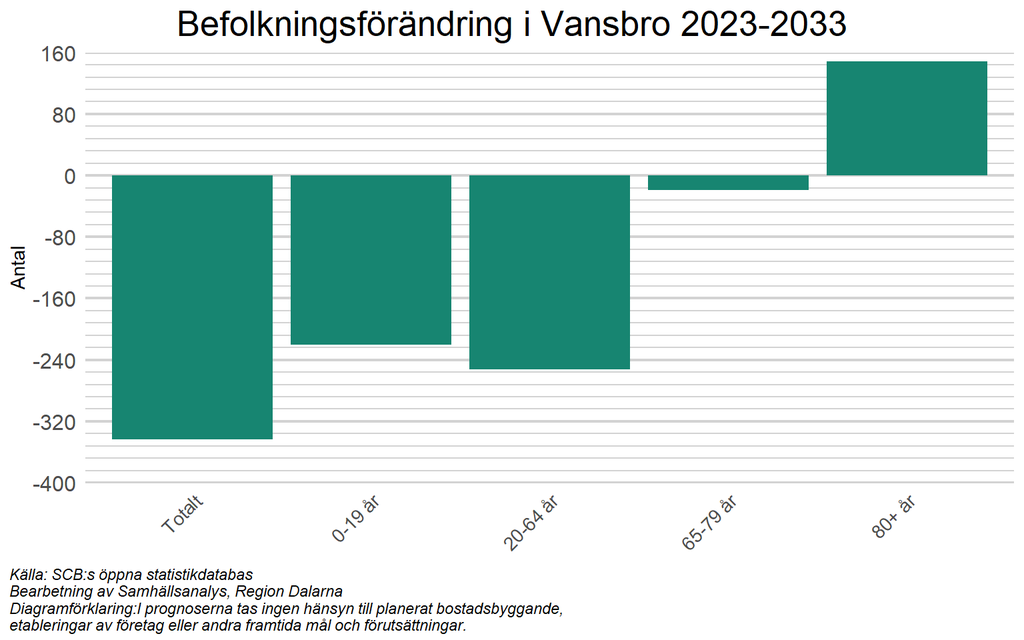